# Relatório Calculadora SST | FPS

Versão Preliminar - SESI | GMAP | UNISINOS

## Dados Gerais

- **Empresa**: Xalingo, Santa Cruz do Sul
- **Participantes Empresa**: Diego Lopes, Jucelaine e Luciano Bredow
- **Participantes SESI**: Iuri Forte, Júlia Schenkel, Fabiane Bublitz

## A Empresa

A Xalingo Brinquedos é uma empresa de Santa Cruz do Sul – RS, que se dedica à fabricação de jogos e brinquedos de plástico e madeira. A Xalingo é uma empresa que se preocupa constantemente com a sustentabilidade, demonstrando isto por meio de ações em toda a sua produção. Além disso, há uma preocupação constante com o bem-estar de seus colaboradores, o que se reflete em ações voltadas à educação, esporte, saúde, entre outros. Destaca-se que a coleta de dados históricos na empresa e, também, a coleta de informações relativas às iniciativas foram conduzidas em 13 e 14 de novembro.

## Coleta de Dados Históricos

Os dados foram coletados utilizando o template do Excel destinado para tal atividade. A relação das variáveis coletadas/arbitradas estão disponíveis nos apêndices. Os dados que não estavam disponíveis (falta de histórico ou controle ainda não realizado na empresa), foram arbitrados com o apoio do grupo, baseado na experiência dos participantes da Xalingo.

## Iniciativas Avaliadas

Para cada iniciativa foram coletados dados referentes aos custos de sua implantação e manutenção, bem como foram estimadas as melhorias que poderão ser obtidas a partir da sua implementação. Estas estimativas foram feitas baseadas na probabilidade de redução dos eventos (afastamentos, óbito), redução de faltas, economias (savings) em produtividade, entre outros.

## Valores Obtidos por Benefício Avaliado

Nesta seção serão apresentados os valores obtidos para o conjunto de benefícios avaliados. Esta apresentação será feita na seguinte ordem de categorias: i) Reduções Fiscais; ii) Despesas Evitáveis; iii) Melhor uso dos recursos; e, iv) Intangível. A sequência de ordenamento da apresentação de resultados parte das categorias cujo os resultados são objetivos em termos de cálculo para elementos indiretos, finalizando em uma categoria intangível na qual as questões subjetivas são incorporadas ao cálculo.

| **Categoria** | **Cálculo do Benefício** | **Objetividade** | **Tangibilidade** |
| --- | --- | --- | --- |
| Reduções Fiscais | Pode ser calculado a priori tendo por referência valores da legislação. | Objetivo e Direto | Tangível |
| Despesas Evitáveis | Pode ser calculado a partir de estimativas da redução de riscos a que organização exposta ou ações que mitiguem os impactos do risco. Pode depender de fatores externos a empresa e as ações de SST e FP… | Objetivo e Indireto | Tangível |
| Melhor uso dos Recursos | É calculado a partir da composição de elementos objetivo/diretos (turnover e absenteísmo, por exemplo) e objetivos/indiretos (produtividade e qualidade, por exemplo) que são consequência das ações de … | Objetivo e Direto/Indireto | Tangível |
| Intangível | O cálculo dessa categoria é realizado externamente a calculadora a partir de questões subjetivas que podem afetar o negócio da empresa. Alguns elementos são estimados, mas são baseados em aspectos int… | Subjetiva e Indireta | Intangível |

## Resultados Gerais - Resumo Por Iniciativa

A seguir é apresentado o resultado geral desta análise por iniciativa.

Estatísticas da Análise de Custo benefício por Iniciativa.

| Cenario.y | Iniciativa 1 | Iniciativa 2 | Iniciativa 3 |
| --- | --- | --- | --- |
| LimiteInferiorCBR | -0.2046635 | -1.1939020 | -0.8797615 |
| MediaCBR | -0.1254197 | -0.8761325 | -0.2708653 |
| LimiteSuperiorCBR | -0.02367215 | -0.46581038 | 0.52229360 |
| ProbCBRMaior1 | 0.000 | 0.000 | 0.003 |
| LimiteInferiorBeneficio | -43651.36 | -65664.61 | -24982.71 |
| MediaBeneficio | -26749.960 | -48187.287 | -7691.799 |
| LimiteSuperiorBeneficio | -5048.882 | -25619.571 | 14831.644 |
| Custo | 213283.59 | 55000.00 | 28397.14 |

### Reduções Fiscais

- **Exposição à Multas:** Esta subcategoria compreende a economia de recursos monetários que empresa pode obter ao reduzir os riscos de não atendimento à legislação (NRs) após a implementação integral do projeto/iniciativa.
- **FAP:** Esta subcategoria compreende a economia de recursos monetários que empresa obtém no RAT Ajustado ao reduzir a quantidade e severidade dos acidentes de trabalho (FAP) após a implementação integral do projeto/iniciativa.

| Cenario.y | Iniciativa 1 | Iniciativa 2 | Iniciativa 3 |
| --- | --- | --- | --- |
| BeneficioMultas | 5092.288 | 5092.288 | 5092.288 |
| BeneficioFAP | 338.9945 | 331.6506 | 346.7631 |

### Despesas Evitáveis

- **Despesas com Reclamatórias Trabalhistas:** Esta subcategoria compreende as despesas evitadas com possíveis reclamatórias trabalhistas (objeto da ação relacionadas às doenças ocupacionais e acidentes do trabalho) após a implementação integral do projeto/iniciativa.
- **Ações Regressivas INSS:** Esta subcategoria compreende as despesas evitadas com ações regressivas do INSS após a implementação integral do projeto/iniciativa.
- **Despesas Médicas:** Esta subcategoria compreende as despesas evitadas com medicamentos e atendimento médico para tratamento dos acidentes de trabalho após a implementação integral do projeto/iniciativa.
- **Reajustes Plano de Saúde:** Esta subcategoria compreende as despesas evitadas com planos de saúde via alteração da taxa de sinistralidade após a implementação integral do projeto/iniciativa.
- **Interrupção Operacional (Acidente/Morte):** Esta subcategoria compreende as despesas evitadas por interrupção, total ou parcial, das operações da empresa devido acidentes de trabalho, óbitos ou interdições após a implementação integral do projeto/iniciativa.
- **Interdições por Fiscalização:** Esta subcategoria compreende as despesas evitadas por interdição, total ou parcial, das operações da empresa devido a fiscalizações após a implementação integral do projeto/iniciativa.
- **Reabilitação do Trabalhador:** Esta subcategoria compreende as despesas evitadas com a reabilitação do trabalhador que esteve afastado por doenças ocupacionais ou acidentes após a implementação integral do projeto/iniciativa.
- **Seguro Patrimonial:** Esta subcategoria compreende os savings que a empresa pode ter no que tange à diminuição das despesas com planos de seguro contra dano material.

| Cenario.y | Iniciativa 1 | Iniciativa 2 | Iniciativa 3 |
| --- | --- | --- | --- |
| BeneficioAcoesRegressivasINSS | 0 | 0 | 0 |
| BeneficioReabilitacao | 0 | 0 | 0 |
| BeneficioPlanodeSaude | 0 | 0 | 0 |
| BeneficioReclamatorias | 22.81262 | -48.94189 | 368.96392 |
| BeneficioDespesasMedicas | -102.3179 | -900.6345 | 4027.8027 |
| BeneficioInterrupcaoAcidentes | 0 | 0 | 0 |
| BeneficioInterdicaoFiscalizacao | 0 | 0 | 0 |
| BeneficioSeguroPatrimonial | 1.522919e-05 | -2.084933e+04 | 1.522919e-05 |

### Melhor Uso dos Recursos

- **Turnover:** Esta subcategoria compreende a economia gerada pela redução da taxa de rotatividade da mão-de-obra após a implementação do projeto/iniciativa em SST e FPS. As variáveis contempladas referem à redução das despesas de recursos humanos e demais áreas de apoio (estrutura, capacitação novos trabalhadores, mobilização e integração de novos trabalhadores, outros).
- **Absenteísmo:** Esta subcategoria compreende a economia gerada pela redução da taxa de absenteísmo da mão-de-obra após a implementação do projeto/iniciativa em SST e FPS. As variáveis contempladas referem à redução das despesas com tempo de realocação de trabalhadores, horas extras necessárias para suprir as carências de mão-de-obra nas operações, entre outras.
- **Presenteísmo:** Esta subcategoria compreende a economia pela redução da taxa de presenteísmo da mão-de-obra após a implementação do projeto/iniciativa em SST e FPS. É uma dimensão intermediária que impacta na produtividade da empresa.
- **Produtividade:** Esta subcategoria compreende os ganhos obtidos pela elevação da produtividade da mão-de-obra devido ao ambiente seguro e saudável. A produtividade pode ser medida em FTE (Full-Time Equivalent) ou volume de produção horária.
- **Qualidade:** Esta subcategoria compreende os ganhos obtidos com elevação da qualidade dos produtos e serviços devido a melhora do ambiente seguro e saudável. O ganho de qualidade do produto pode resultar em ganho de Market-share e/ou aumento do preço de venda.
- **Refugo/Retrabalho:** Esta subcategoria compreende a economia gerada pela redução do volume de refugos/retrabalhos gerados nas operações após a implementação do projeto/iniciativa em SST e FPS.
- **MP, insumos, equipamentos da operação:** Esta subcategoria compreende a economia gerada pela redução do volume manutenção corretiva (mão-de-obra e materiais) e substituição de máquinas e ferramentas após a implementação da iniciativa em SST e FPS.

| Cenario.y | Iniciativa 1 | Iniciativa 2 | Iniciativa 3 |
| --- | --- | --- | --- |
| BeneficioTurnover | 30.17648 | -64.74022 | 488.06465 |
| BeneficioAbsenteismo | -32134.71 | -31741.58 | -18060.93 |
| BeneficioPresenteismo | 0 | 0 | 0 |
| BeneficioGanhoProdutividade | 0 | 0 | 0 |
| BeneficioGanhoQualidade | 0 | 0 | 0 |
| BeneficioRefugoERetrabalho | 0 | 0 | 0 |
| BeneficioMPInsumos | 0 | 0 | 0 |

### Benefícios Intangíveis

- **Imagem da Empresa:** Esta subcategoria compreende os ganhos que a empresa pode obter com elevação da sua imagem devido à boas práticas de segurança e de evidenciação de aspectos que evidenciem a busca pelo aumento da qualidade de vida dos seus trabalhadores (e.g. facilidade no processo de atração e retenção de talentos) após a implementação integral do projeto/iniciativa.
- **Engajamento e Clima organizacional:** Esta subcategoria compreende os ganhos devido ao engajamento dos trabalhadores e elevação do clima organizacional devido ao ambiente saudável e seguro. É uma dimensão intermediária que impacta na produtividade da empresa.

| Cenario.y | Iniciativa 1 | Iniciativa 2 | Iniciativa 3 |
| --- | --- | --- | --- |
| BeneficioImagemContratacao | 2.797836 | -6.002441 | 45.251302 |
| BeneficioGanhoImagemReceita | 0 | 0 | 0 |
| BeneficioClima | 0 | 0 | 0 |

## Gráficos por Iniciativa

Os gráficos que serão expostos a seguir apresentam como cada dimensão contribui para a geração da razão benefício-custo total. A partir destes, é possível visualizar a importância relativa de cada umas das categorias na Razão Benefício-Custo apresentado para cada iniciativa.

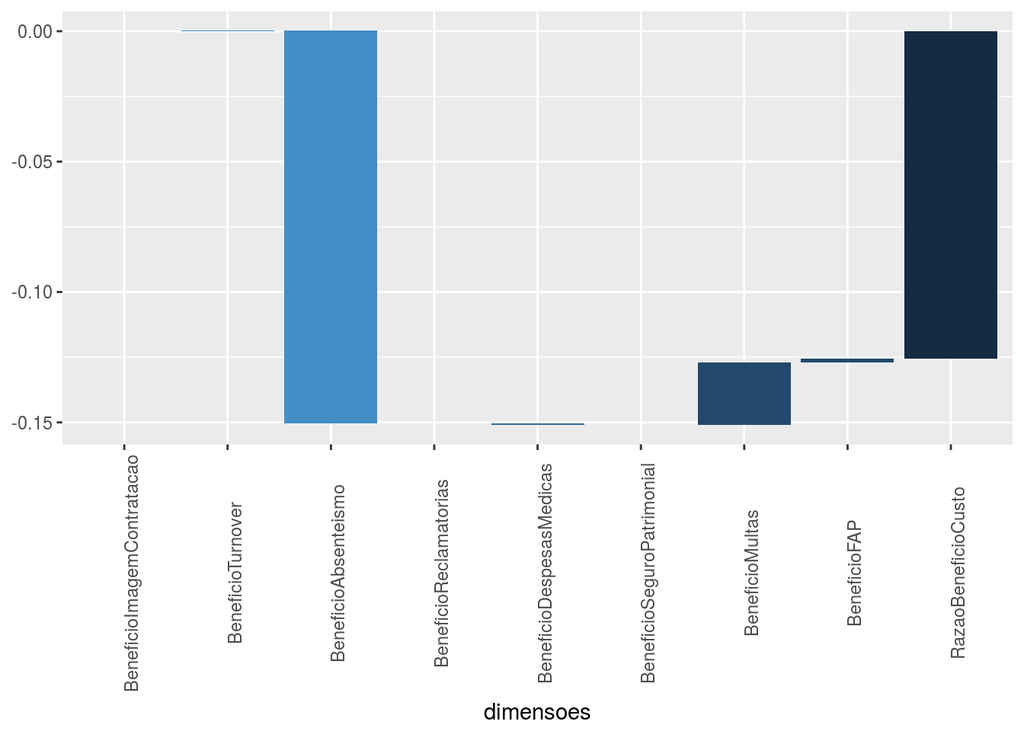

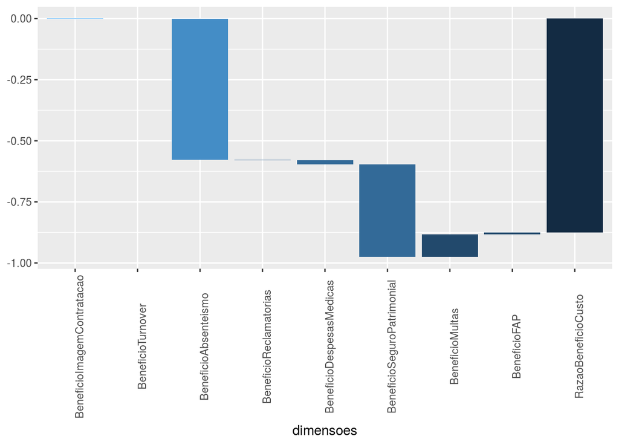

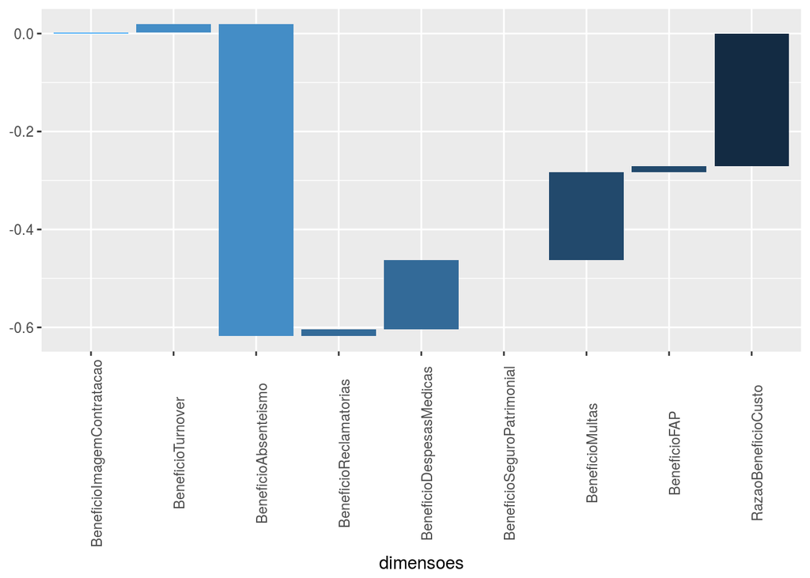

### Observação da Variabilidade das Iniciativas:

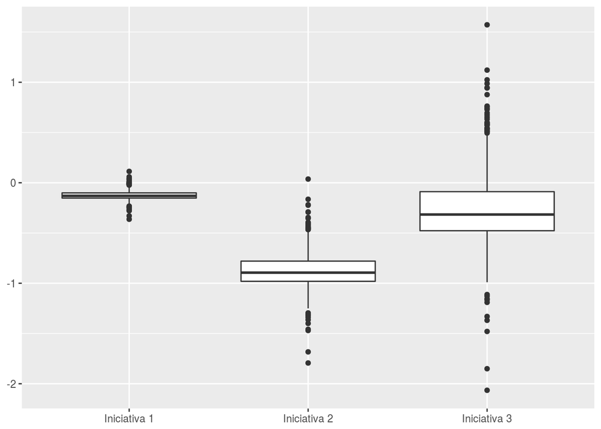

## Apêndice - Registros para a Reprodutibilidade dos Calculos

### Logs

A seguir são apresentados os logs de execução gerados pela calculadora.

| Logs |
| --- |
| 2017-11-19 11:29:55 - ### CALCULADORA SESI / GMAP \| UNISINOS - LOGS DE EXECUÇÃO ### |
| 2017-11-19 11:29:55 - Versão: 1.5.0 |
| 2017-11-19 11:29:55 - ### Iniciando Importação de Dados Tratados. |
| 2017-11-19 11:29:55 - Interface de Dados: Constantes |
| 2017-11-19 11:29:55 - Interface de Dados: Configurações |
| 2017-11-19 11:29:55 - Interface de Dados: Cenários |
| 2017-11-19 11:29:55 - Aviso: Existem Variaveis com NA: NomeIniciativa, AnosDelay . Substutindo valores por 0 |
| 2017-11-19 11:29:55 - Interface de Dados: Dados Projetados |
| 2017-11-19 11:29:55 - Interface de Dados: Custos |
| 2017-11-19 11:29:55 - Aviso: Existem Variaveis com NA: CustoTotal . Substutindo valores por 0 |
| 2017-11-19 11:29:55 - Interface de Dados: Histórico FAP |
| 2017-11-19 11:29:55 - Aviso: Variável NB_92, NB_93 não está no arquivo de tratamento de dados. Considerando variável igual a zero. |
| 2017-11-19 11:29:55 - Aviso: Existem Variaveis com NA: NB_94 . Substutindo valores por 0 |
| 2017-11-19 11:29:55 - Interface de Dados: Parâmetros |
| 2017-11-19 11:29:55 - Buscando parâmetros - ASIS |
| 2017-11-19 11:29:55 - Buscando parâmetros - Iniciativa 1 |
| 2017-11-19 11:29:55 - Aviso: Multas1 não localizada no arquivo de dados tratados. Valor da variavel: |
| 2017-11-19 11:29:55 - Aviso: Multas2 não localizada no arquivo de dados tratados. Valor da variavel: |
| 2017-11-19 11:29:55 - Aviso: Multas3 não localizada no arquivo de dados tratados. Valor da variavel: |
| 2017-11-19 11:29:55 - Aviso: Multas4 não localizada no arquivo de dados tratados. Valor da variavel: |
| 2017-11-19 11:29:55 - Aviso: Multas5 não localizada no arquivo de dados tratados. Valor da variavel: |
| 2017-11-19 11:29:55 - Buscando parâmetros - Iniciativa 2 |
| 2017-11-19 11:29:55 - Aviso: Multas1 não localizada no arquivo de dados tratados. Valor da variavel: |
| 2017-11-19 11:29:55 - Aviso: Multas2 não localizada no arquivo de dados tratados. Valor da variavel: |
| 2017-11-19 11:29:55 - Aviso: Multas3 não localizada no arquivo de dados tratados. Valor da variavel: |
| 2017-11-19 11:29:55 - Aviso: Multas4 não localizada no arquivo de dados tratados. Valor da variavel: |
| 2017-11-19 11:29:55 - Aviso: Multas5 não localizada no arquivo de dados tratados. Valor da variavel: |
| 2017-11-19 11:29:55 - Buscando parâmetros - Iniciativa 3 |
| 2017-11-19 11:29:55 - Aviso: Multas1 não localizada no arquivo de dados tratados. Valor da variavel: |
| 2017-11-19 11:29:55 - Aviso: Multas2 não localizada no arquivo de dados tratados. Valor da variavel: |
| 2017-11-19 11:29:55 - Aviso: Multas3 não localizada no arquivo de dados tratados. Valor da variavel: |
| 2017-11-19 11:29:55 - Aviso: Multas4 não localizada no arquivo de dados tratados. Valor da variavel: |
| 2017-11-19 11:29:55 - Aviso: Multas5 não localizada no arquivo de dados tratados. Valor da variavel: |
| 2017-11-19 11:29:55 - ### Finalizando Importação de Dados Tratados. |
| 2017-11-19 11:30:17 - ### Iniciando Simulação de Custos e Benefícios em SST e FPS. |
| 2017-11-19 11:30:17 - obter_parametros.R/obter_parametros: Iniciando Obtencao de Parametros: funcao obter_parametros(inputs). |
| 2017-11-19 11:30:22 - obter_parametros.R/obter_parametros: Finalizando obtencao de parametros. |
| 2017-11-19 11:30:22 - Iniciando Verificacao de Parâmetros. |
| 2017-11-19 11:30:22 - Terminando Verificação de Parâmetros. |
| 2017-11-19 11:30:22 - simular: Iniciando Calculo dos Resultados do Modelo. |
| 2017-11-19 11:30:22 - calcular_funcoes: Funcao Calculada: calcular_eventos |
| 2017-11-19 11:30:22 - calcular_funcoes: Funcao Calculada: calcular_faltas |
| 2017-11-19 11:30:22 - calcular_funcoes: Funcao Calculada: calcular_taxas_acidentes |
| 2017-11-19 11:30:22 - Aviso: variavel PercDesligamentoVoluntarios assumium um valor maior do que 0.25 . O valor máximo foi considerado em 100 % dos casos. |
| 2017-11-19 11:30:22 - calcular_funcoes: Funcao Calculada: calcular_turnovergeral |
| 2017-11-19 11:30:22 - calcular_funcoes: Funcao Calculada: calcular_absenteismo |
| 2017-11-19 11:30:23 - calcular_funcoes: Funcao Calculada: calcular_turnover |
| 2017-11-19 11:30:23 - calcular_funcoes: Funcao Calculada: calcular_beneficios_inss |
| 2017-11-19 11:30:23 - simular: Simulando FAP. |
| 2017-11-19 11:30:23 - calcular_funcoes: Funcao Calculada: calcular_multas |
| 2017-11-19 11:30:23 - calcular_funcoes: Funcao Calculada: calcular_acoes_regressivas_inss |
| 2017-11-19 11:30:23 - calcular_funcoes: Funcao Calculada: calcular_presenteismo |
| 2017-11-19 11:30:23 - calcular_funcoes: Funcao Calculada: calcular_despesasmedicas |
| 2017-11-19 11:30:23 - calcular_funcoes: Funcao Calculada: calcular_refugo_retrabalho |
| 2017-11-19 11:30:23 - calcular_funcoes: Funcao Calculada: calcular_mp_insumos |
| 2017-11-19 11:30:23 - calcular_funcoes: Funcao Calculada: calcular_engajamento |
| 2017-11-19 11:30:23 - calcular_funcoes: Funcao Calculada: calcular_reclamatorias |
| 2017-11-19 11:30:26 - calcular_funcoes: Funcao Calculada: calcular_reajustes_plano |
| 2017-11-19 11:30:26 - calcular_funcoes: Funcao Calculada: calcular_reabilitacao |
| 2017-11-19 11:30:26 - calcular_funcoes: Funcao Calculada: calcular_produtividade |
| 2017-11-19 11:30:26 - calcular_funcoes: Funcao Calculada: calcular_qualidade |
| 2017-11-19 11:30:26 - calcular_funcoes: Funcao Calculada: calcular_imagem_contracacao |
| 2017-11-19 11:30:26 - calcular_funcoes: Funcao Calculada: calcular_imagem_receita |
| 2017-11-19 11:30:27 - calcular_funcoes: Funcao Calculada: calcular_interrupcao_acidentes |
| 2017-11-19 11:30:27 - calcular_funcoes: Funcao Calculada: calcular_interdicao_fiscalizacao |
| 2017-11-19 11:30:27 - calcular_funcoes: Funcao Calculada: calcular_seguro_patrimonial |
| 2017-11-19 11:30:27 - simular: Finalizando Calculo dos Resultados do Modelo. |
| 2017-11-19 11:30:27 - descontar_fluxo_de_caixa: Iniciando Calculo do Valor Presente Liquido das variaveis. |
| 2017-11-19 11:30:27 - calcular_cbr: Inciando Calculo da Razao Custo Beneficio. |
| 2017-11-19 11:30:27 - calcular_cbr: Finalizando Calculo da Razao Custo Beneficio. |
| 2017-11-19 11:30:27 - simular: Finalizando Simulacao. |

### Probabilidades Informadas

- **Configurações**

| AnoInicial | TaxaDeDesconto | FuncionariosBase | NomeAnalista | HorizonteAvaliacao |
| --- | --- | --- | --- | --- |
| 2018 | 0.1 | 434.5 | Luis Camargo | 5 |

- **Dados Projetados**

| Ano | Crise | FatorCrise | VarPIB |
| --- | --- | --- | --- |
| 2018 | 0 | 10 | 0.03 |
| 2019 | 1 | 10 | 0.02 |
| 2020 | 1 | 10 | 0.04 |
| 2021 | 0 | 10 | 0.05 |
| 2022 | 0 | 10 | 0.02 |

- **Constantes**

| Variavel | Valor | Estimar? | Fonte |
| --- | --- | --- | --- |
| Funcionarios | 434.50 | Sim | Último Ano |
| FolhadePagamento | 10757557.17 | Sim | Último Ano |
| RATTabela | 0.03 | Sim | Último Ano |
| DiasUteis | 235.00 | Sim | Média |
| HorasPorDia | 8.21 | Sim | Média |
| CustoMDO | 9.65 | Sim | Média |
| NB_91_Inicial | 40.00 | Sim | Média |
| NB_92_Inicial | 0.00 | Sim | Média |
| NB_93_Inicial | 0.00 | Sim | Média |
| NB_94_Inicial | 2.00 | Sim | Média |
| DesligamentosInvoluntarios | 293.40 | Sim | Média |
| DespesasPlanoInicial | 130587.94 | Sim | Média |
| TFrMaximaImagem | 0.00 | Não | Média |
| TGrMaximaImagem | 0.00 | Não | Média |
| FatorAjusteExposicaoAoRisco | 0.83 | Sim | Média |
| CustoMedSubstitu | 364.73 | Sim | Média |
| PInvalidez | 1.00 | Sim | Média |
| PercPresenteismo | 0.00 | Não | Média |
| CustoMedioRefugoRetrabalho | 0.00 | Não | Média |
| CustoMedioMPInsumos | 0.00 | Não | Média |
| PReclamatoria | 0.02 | Sim | Média |
| CustoMedioReclamatorias | 18235.56 | Sim | Média |
| PercentualReabilitacao | 0.00 | Não | Média |
| CustoMedioReabilitacao | 0.00 | Não | Média |
| CustoMedSubstituporTempo | 4.90 | Não | Média |
| CustoMedio_NB_91 | 1630.08 | Sim | Média |
| CustoMedio_NB_92 | 0.00 | Sim | Média |
| CustoMedio_NB_93 | 0.00 | Sim | Média |
| CustoMedio_NB_94 | 103517.26 | Sim | Média |
| Beta0ReajustePlano | 0.75 | Sim | Média |
| BetaFreqReajustePlano | 0.00 | Sim | Média |
| BetaGravReajustePlano | 0.00 | Sim | Média |
| Beta0TempoContratacao | 38.40 | Não | Média |
| BetaPIBTempoContratacao | 0.00 | Não | Média |
| BetaFreqTempoContratacao | 0.00 | Não | Média |
| BetaGravTempoContratacao | 0.00 | Não | Média |
| TempoContratacaoPadrao | 31.50 | Não | Média |
| Beta0IFrequenciaFAP | 35.85 | Sim | Média |
| Beta1IFrequenciaFAP | 0.32 | Sim | Média |
| Beta0IGravidadeFAP | 39.07 | Sim | Média |
| Beta1IGravidadeFAP | 5.00 | Sim | Média |
| Beta0ICustoFAP | 47.29 | Sim | Média |
| Beta1ICustoFAP | 2.45 | Sim | Média |
| Beta0DesligVoluntarios | 169.50 | Sim | Média |
| BetaPIBDesigVoluntarios | 2010.45 | Sim | Média |
| BetaFreqDesligVoluntarios | 0.00 | Sim | Média |
| BetaGravDesligVoluntarios | 0.00 | Sim | Média |
| FatorB91 | 1.00 | Sim | Média |
| FatorB92 | 0.00 | Sim | Média |
| FatorB93 | 1.00 | Sim | Média |
| FatorB94 | 0.00 | Sim | Média |
| DiasMedAfast_Men15 | 6.51 | Sim | Média |
| DespesaMedicaMedia | 115.31 | Sim | Média |

- **Parâmetros**

| NomeVariavel | Distribuicao | Parametro1 | Parametro2 |
| --- | --- | --- | --- |
| PAcaoRegressiva | normal | 0.0000 | 0.0000 |
| EventoInterdicao | poisson | 0.0000 | 0.0000 |
| Pev_Afmenor15_Tipico | normaltruncada | 0.0315 | 0.0119 |
| Pev_Afmaior15_Tipico | normaltruncada | 0.0039 | 0.0025 |
| Pev_Safast_Tipico | normaltruncada | 0.0409 | 0.0110 |
| Pev_Obito_Tipico | poisson_percentual_eventos | 0.0133 | 0.0000 |
| Pev_Afmenor15_Trajeto | normaltruncada | 0.0039 | 0.0060 |
| Pev_Afmaior15_Trajeto | normaltruncada | 0.0020 | 0.0016 |
| Pev_Safast_Trajeto | normaltruncada | 0.0039 | 0.0039 |
| Pev_Obito_Trajeto | normal | 0.0000 | 0.0000 |
| Pev_Afmenor15_DoenOcup | normal | 0.0039 | 0.0109 |
| Pev_Afmaior15_DoenOcup | normaltruncada | 0.0020 | 0.0023 |
| Pev_Safast_DoenOcup | normal | 0.0091 | 0.0072 |
| Pev_Obito_DoenOcup | normal | 0.0000 | 0.0000 |
| Pev_Afmenor15_NRelac | normal | 0.0000 | 0.0000 |
| Pev_Afmaior15_NRelac | normal | 0.0000 | 0.0000 |
| Pev_Safast_NRelac | normal | 0.0000 | 0.0000 |
| Pev_Obito_NRelac | normal | 0.0000 | 0.0000 |
| TaxaFaltas | normaltruncada | 1.3075 | 0.6789 |
| LucroCessanteAcidenteObito | normaltruncada | 0.0000 | 0.0000 |
| LucroCessanteAcidenteOutros | normaltruncada | 0.0000 | 0.0000 |
| LucroCessanteInterdicaoFiscalizacao | normaltruncada | 0.0000 | 0.0000 |
| TempoComputadoMedio | normaltruncada | 7.7910 | 6.8560 |
| DespesasSeguroPatrimonial | triangular | 0.0000 | 0.0000 |
| DespesaExposicaoMulta1 | normal | 1051.9480 | 2352.2272 |
| DespesaExposicaoMulta2 | normal | 1207.5960 | 2700.2667 |
| DespesaExposicaoMulta3 | triangular | 0.0000 | 0.0000 |
| DespesaExposicaoMulta4 | triangular | 0.0000 | 0.0000 |
| DespesaExposicaoMulta5 | triangular | 0.0000 | 0.0000 |
| Multas1 | poisson | 0.6000 | 0.0000 |

[output cut: 118 more lines]

- **Cenários**

| Cenario | NomeIniciativa | Simular | CenarioASIS | AnosDelay |
| --- | --- | --- | --- | --- |
| ASIS | AS IS | TRUE | TRUE | 0 |
| Iniciativa 1 | PTA | TRUE | FALSE | 0 |
| Iniciativa 2 | Cabine de modelagem | TRUE | FALSE | 0 |
| Iniciativa 3 | Adequação NR12 Serra circular | TRUE | FALSE | 0 |
| Iniciativa 4 | NA | FALSE | FALSE | 0 |
| Iniciativa 5 | NA | FALSE | FALSE | 0 |
| Iniciativa 6 | NA | FALSE | FALSE | 0 |
| Iniciativa 7 | NA | FALSE | FALSE | 0 |
| Iniciativa 8 | NA | FALSE | FALSE | 0 |
| Iniciativa 9 | NA | FALSE | FALSE | 0 |
| Iniciativa 10 | NA | FALSE | FALSE | 0 |

- **Custos**

| Cenario | Categoria | Ano | CustoTotal |
| --- | --- | --- | --- |
| ASIS | Custo Total | 2018 | 0 |
| ASIS | Custo Total | 2019 | 0 |
| ASIS | Custo Total | 2020 | 0 |
| ASIS | Custo Total | 2021 | 0 |
| ASIS | Custo Total | 2022 | 0 |
| Iniciativa 1 | Custo Total | 2018 | 180000 |
| Iniciativa 1 | Custo Total | 2019 | 10500 |
| Iniciativa 1 | Custo Total | 2020 | 10500 |
| Iniciativa 1 | Custo Total | 2021 | 10500 |
| Iniciativa 1 | Custo Total | 2022 | 10500 |
| Iniciativa 2 | Custo Total | 2018 | 55000 |
| Iniciativa 2 | Custo Total | 2019 | 0 |
| Iniciativa 2 | Custo Total | 2020 | 0 |
| Iniciativa 2 | Custo Total | 2021 | 0 |
| Iniciativa 2 | Custo Total | 2022 | 0 |
| Iniciativa 3 | Custo Total | 2018 | 25000 |
| Iniciativa 3 | Custo Total | 2019 | 1250 |
| Iniciativa 3 | Custo Total | 2020 | 1000 |
| Iniciativa 3 | Custo Total | 2021 | 1000 |
| Iniciativa 3 | Custo Total | 2022 | 1000 |

- **Módulos Selecionados**

| Modulo | Calcular | Obrigatorio | Categoria | NomeBeneficioDadosEntrada |
| --- | --- | --- | --- | --- |
| calcular_faltas | TRUE | 1 | Base | Nenhum |
| calcular_eventos | TRUE | 1 | Base | Nenhum |
| calcular_turnover | TRUE | 1 | Melhor Uso dos Recursos | BeneficioTurnover |
| calcular_absenteismo | TRUE | 1 | Melhor Uso dos Recursos | BeneficioAbsenteismo |
| calcular_acoes_regressivas_inss | TRUE | 0 | Despesas Evitáveis | BeneficioAcoesRegressivasINSS |
| calcular_beneficios_inss | TRUE | 1 | Base | Nenhum |
| calcular_presenteismo | TRUE | 0 | Melhor Uso dos Recursos | BeneficioPresenteismo |
| calcular_despesasmedicas | TRUE | 0 | Despesas Evitáveis | BeneficioDespesasMedicas |
| calcular_refugo_retrabalho | TRUE | 0 | Melhor Uso dos Recursos | BeneficioRefugoERetrabalho |
| calcular_mp_insumos | TRUE | 0 | Melhor Uso dos Recursos | BeneficioMPInsumos |
| calcular_engajamento | TRUE | 0 | Intangível | BeneficioClima |
| calcular_turnovergeral | TRUE | 1 | Base | Nenhum |
| calcular_reclamatorias | TRUE | 0 | Despesas Evitáveis | BeneficioReclamatorias |
| calcular_reajustes_plano | TRUE | 0 | Despesas Evitáveis | BeneficioPlanodeSaude |
| calcular_reabilitacao | TRUE | 0 | Despesas Evitáveis | BeneficioReabilitacao |
| calcular_produtividade | TRUE | 0 | Melhor Uso dos Recursos | BeneficioGanhoProdutividade |
| calcular_qualidade | TRUE | 0 | Melhor Uso dos Recursos | BeneficioGanhoQualidade |
| calcular_imagem_contracacao | TRUE | 0 | Intangível | BeneficioImagemContratacao |
| calcular_imagem_receita | TRUE | 0 | Intangível | BeneficioImagemContratacao |
| calcular_multas | TRUE | 0 | Reduções Fiscais | BeneficioMultas |
| calcular_interrupcao_acidentes | TRUE | 0 | Despesas Evitáveis | BeneficioInterrupcaoAcidentes |
| calcular_interdicao_fiscalizacao | TRUE | 0 | Despesas Evitáveis | BeneficioInterdicaoFiscalizacao |
| calcular_fap | TRUE | 1 | Reduções Fiscais | BeneficioFAP |
| calcular_seguro_patrimonial | TRUE | 0 | Despesas Evitáveis | BeneficioSeguroPatrimonial |
| calcular_taxas_acidentes | TRUE | 1 | Base | Nenhum |

- **Histórico FAP**

  |  | 2014 | 2015 |
  | --- | --- | --- |
  | Ano | 2.014000e+03 | 2.015000e+03 |
  | NB_91 | 5.000000e+00 | 3.000000e+00 |
  | NB_92 | 0.000000e+00 | 0.000000e+00 |
  | NB_93 | 0.000000e+00 | 0.000000e+00 |
  | NB_94 | 0.000000e+00 | 0.000000e+00 |
  | Funcionarios | 5.891667e+02 | 5.065833e+02 |
  | FolhadePagamento | 8.633910e+06 | 9.881249e+06 |
  | TurnoverGeral | 9.467090e-01 | 1.104808e+00 |
  | CustoMedio_NB_91 | 1.630085e+03 | 1.630085e+03 |
  | CustoMedio_NB_92 | 0.000000e+00 | 0.000000e+00 |
  | CustoMedio_NB_93 | 0.000000e+00 | 0.000000e+00 |
  | CustoMedio_NB_94 | 1.035173e+05 | 1.035173e+05 |
  | CustoTotalBeneficiosFAP | 9.731600e+03 | 1.552860e+04 |
  | RATAjustado | 3.000000e-02 | 3.000000e-02 |